# examples_1215

Quadratic functions are often expressed in [vertex form](https://en.wikipedia.org/wiki/Quadratic_function#Forms_of_a_univariate_quadratic_function):

$$y~=~a(x-h)^2+k$$

From the graph below, determine the values of the 3 parameters.

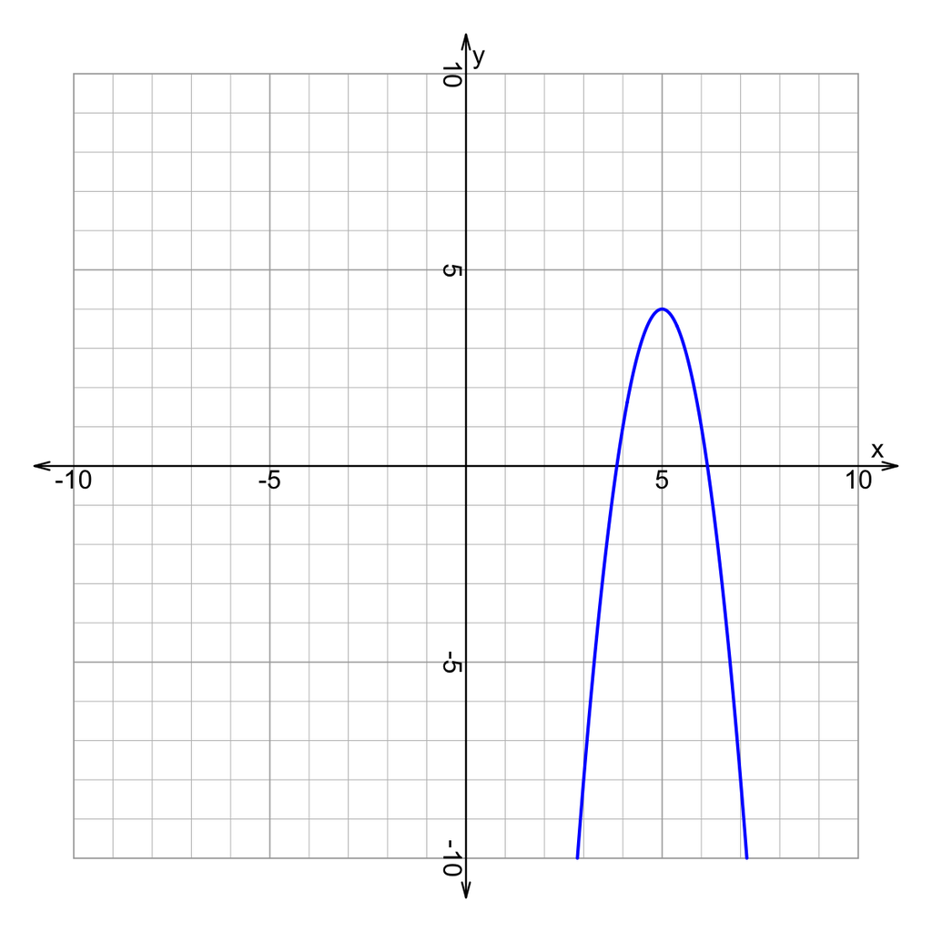

- $a=$
- $h=$
- $k=$

Based on function transformations, it should be clear that the vertex is at point $(h,k)$ and parameter $a$ dictates the vertical stretch and possible vertical reflection (which flips the parabola upside down, such that it looks like a hill, not a valley).

When determining $a$ from a graph, it is easiest to identify the point on the curve 1 unit to the right of the vertex. That point will be at $(h+1,k+a)$. By subtracting the $y$ value of the vertex from the $y$ value of that point 1 unit to the right, it is easy to find $a$.

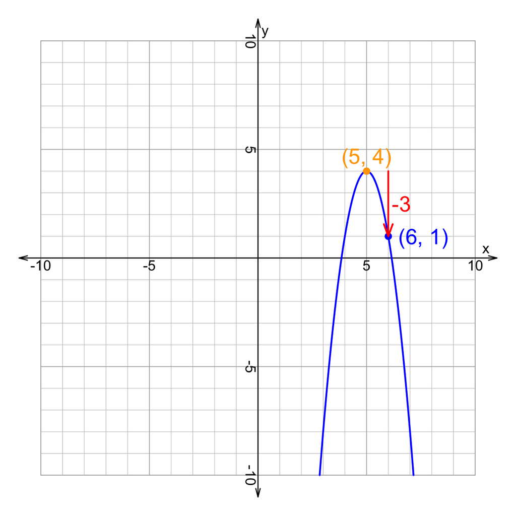

$$(1)-(4)~=~ -3$$

So,

- $a=-3$
- $h=5$
- $k=4$

Thus, the equation of the curve is:
$$y~=~-3(x-5)^2+4$$

Quadratic functions are often expressed in [vertex form](https://en.wikipedia.org/wiki/Quadratic_function#Forms_of_a_univariate_quadratic_function):

$$y~=~a(x-h)^2+k$$

From the graph below, determine the values of the 3 parameters.

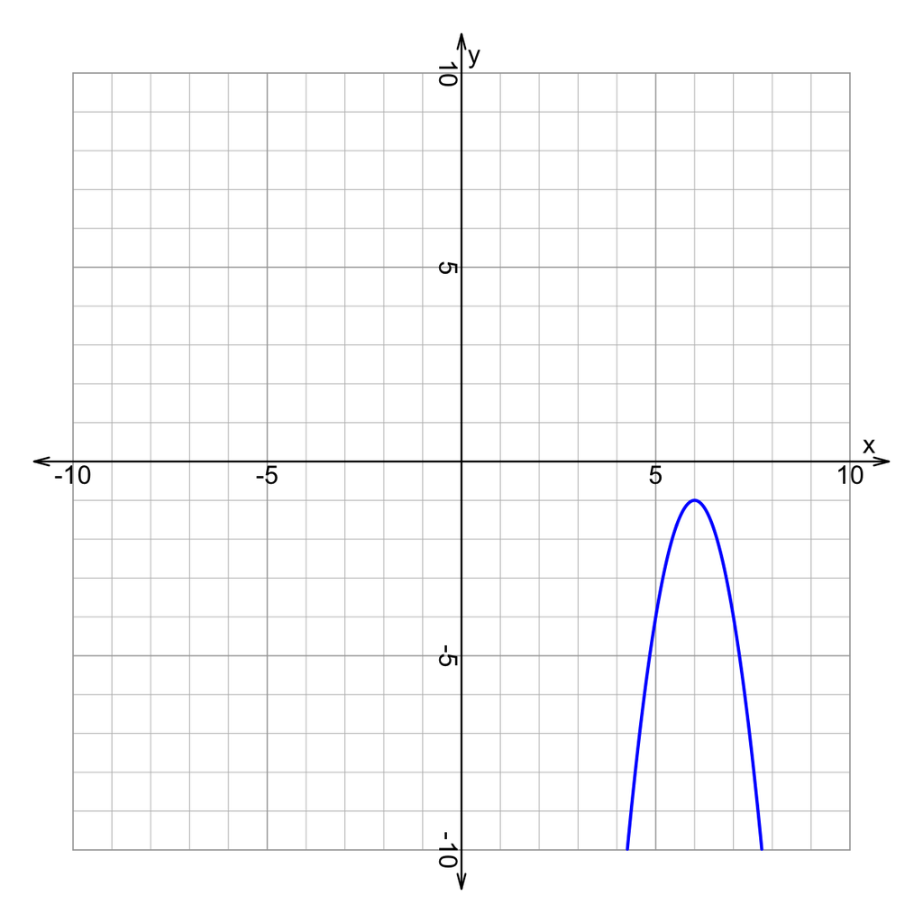

- $a=$
- $h=$
- $k=$

Based on function transformations, it should be clear that the vertex is at point $(h,k)$ and parameter $a$ dictates the vertical stretch and possible vertical reflection (which flips the parabola upside down, such that it looks like a hill, not a valley).

When determining $a$ from a graph, it is easiest to identify the point on the curve 1 unit to the right of the vertex. That point will be at $(h+1,k+a)$. By subtracting the $y$ value of the vertex from the $y$ value of that point 1 unit to the right, it is easy to find $a$.

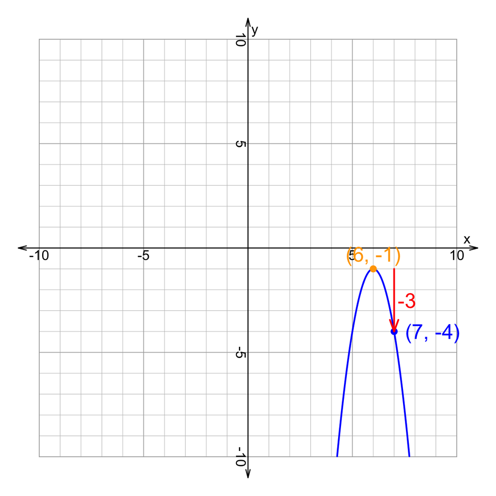

$$(-4)-(-1)~=~ -3$$

So,

- $a=-3$
- $h=6$
- $k=-1$

Thus, the equation of the curve is:
$$y~=~-3(x-6)^2-1$$

Quadratic functions are often expressed in [vertex form](https://en.wikipedia.org/wiki/Quadratic_function#Forms_of_a_univariate_quadratic_function):

$$y~=~a(x-h)^2+k$$

From the graph below, determine the values of the 3 parameters.

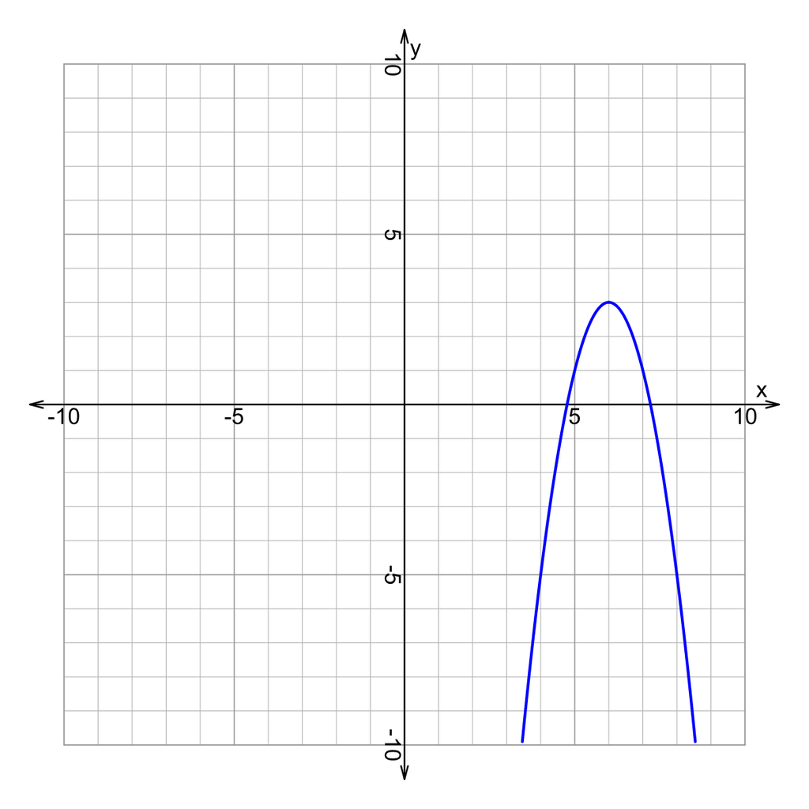

- $a=$
- $h=$
- $k=$

Based on function transformations, it should be clear that the vertex is at point $(h,k)$ and parameter $a$ dictates the vertical stretch and possible vertical reflection (which flips the parabola upside down, such that it looks like a hill, not a valley).

When determining $a$ from a graph, it is easiest to identify the point on the curve 1 unit to the right of the vertex. That point will be at $(h+1,k+a)$. By subtracting the $y$ value of the vertex from the $y$ value of that point 1 unit to the right, it is easy to find $a$.

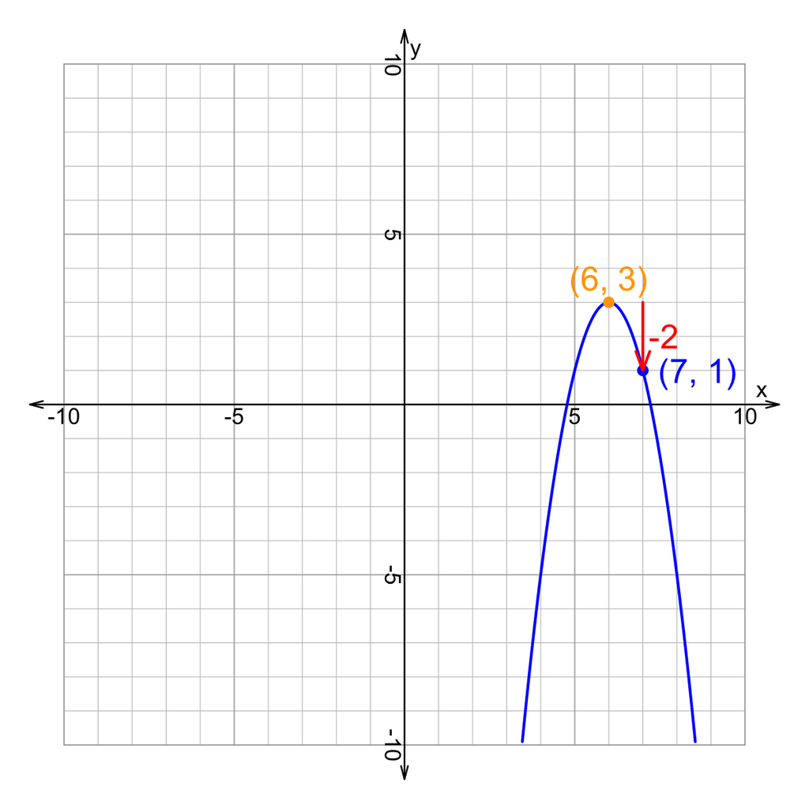

$$(1)-(3)~=~ -2$$

So,

- $a=-2$
- $h=6$
- $k=3$

Thus, the equation of the curve is:
$$y~=~-2(x-6)^2+3$$

Quadratic functions are often expressed in [vertex form](https://en.wikipedia.org/wiki/Quadratic_function#Forms_of_a_univariate_quadratic_function):

$$y~=~a(x-h)^2+k$$

From the graph below, determine the values of the 3 parameters.

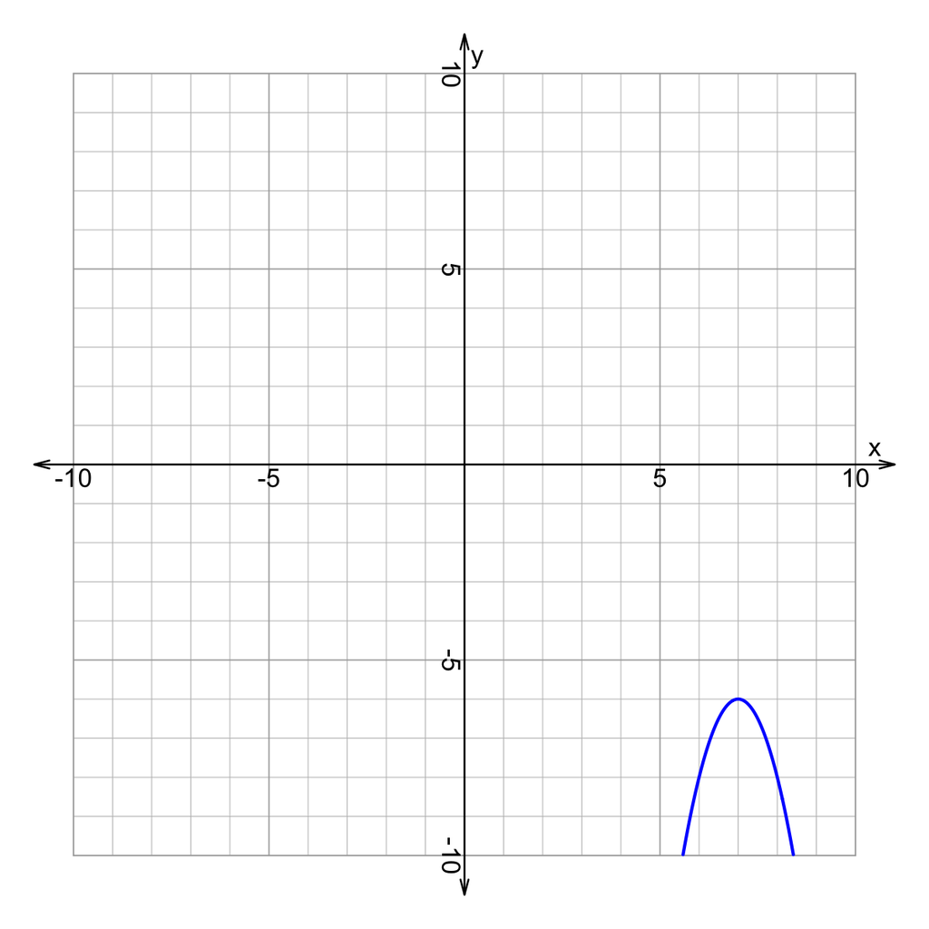

- $a=$
- $h=$
- $k=$

Based on function transformations, it should be clear that the vertex is at point $(h,k)$ and parameter $a$ dictates the vertical stretch and possible vertical reflection (which flips the parabola upside down, such that it looks like a hill, not a valley).

When determining $a$ from a graph, it is easiest to identify the point on the curve 1 unit to the right of the vertex. That point will be at $(h+1,k+a)$. By subtracting the $y$ value of the vertex from the $y$ value of that point 1 unit to the right, it is easy to find $a$.

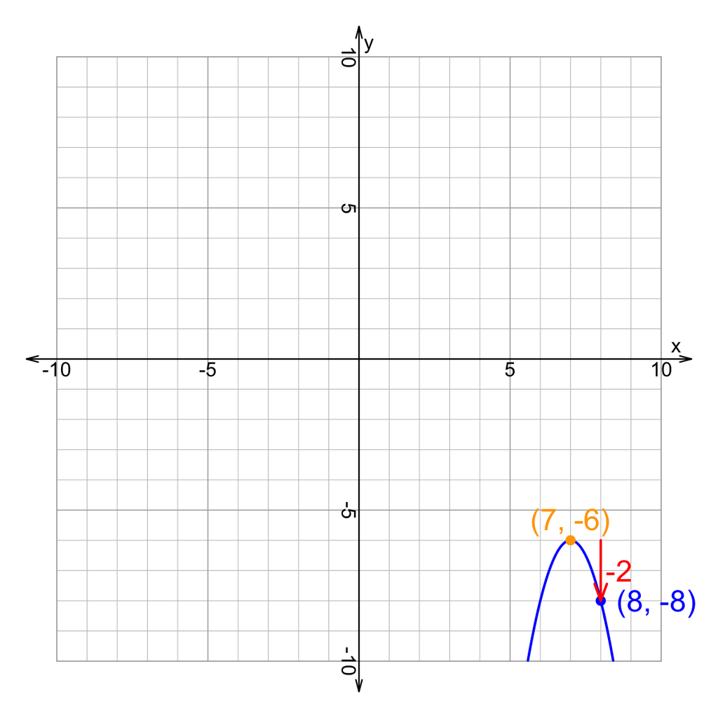

$$(-8)-(-6)~=~ -2$$

So,

- $a=-2$
- $h=7$
- $k=-6$

Thus, the equation of the curve is:
$$y~=~-2(x-7)^2-6$$

Quadratic functions are often expressed in [vertex form](https://en.wikipedia.org/wiki/Quadratic_function#Forms_of_a_univariate_quadratic_function):

$$y~=~a(x-h)^2+k$$

From the graph below, determine the values of the 3 parameters.

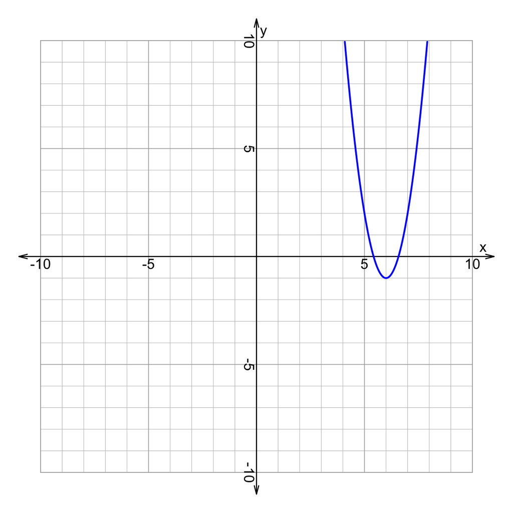

- $a=$
- $h=$
- $k=$

Based on function transformations, it should be clear that the vertex is at point $(h,k)$ and parameter $a$ dictates the vertical stretch and possible vertical reflection (which flips the parabola upside down, such that it looks like a hill, not a valley).

When determining $a$ from a graph, it is easiest to identify the point on the curve 1 unit to the right of the vertex. That point will be at $(h+1,k+a)$. By subtracting the $y$ value of the vertex from the $y$ value of that point 1 unit to the right, it is easy to find $a$.

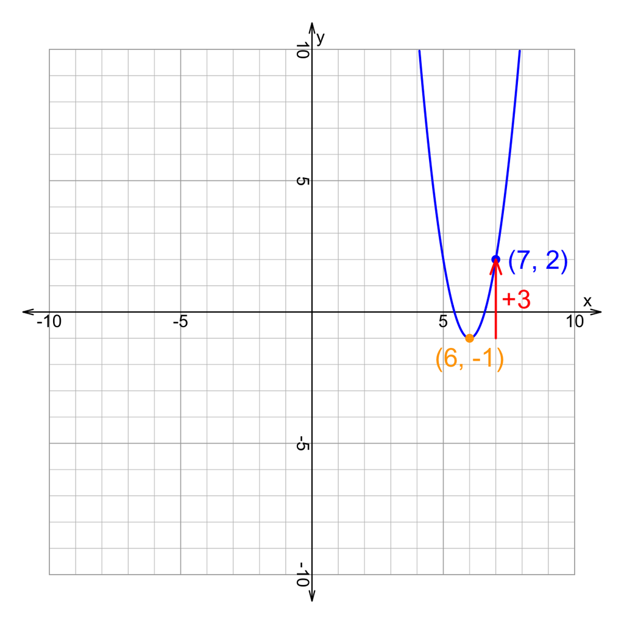

$$(2)-(-1)~=~ 3$$

So,

- $a=3$
- $h=6$
- $k=-1$

Thus, the equation of the curve is:
$$y~=~3(x-6)^2-1$$

A transformed square-root function was constructed by randomly choosing integers for the values of $m$, $p$, $h$, and $k$ in the equation below.

$$y~=~m\sqrt{\frac{1}{p}(x-h)}+k$$

The equation's curve is plotted below:

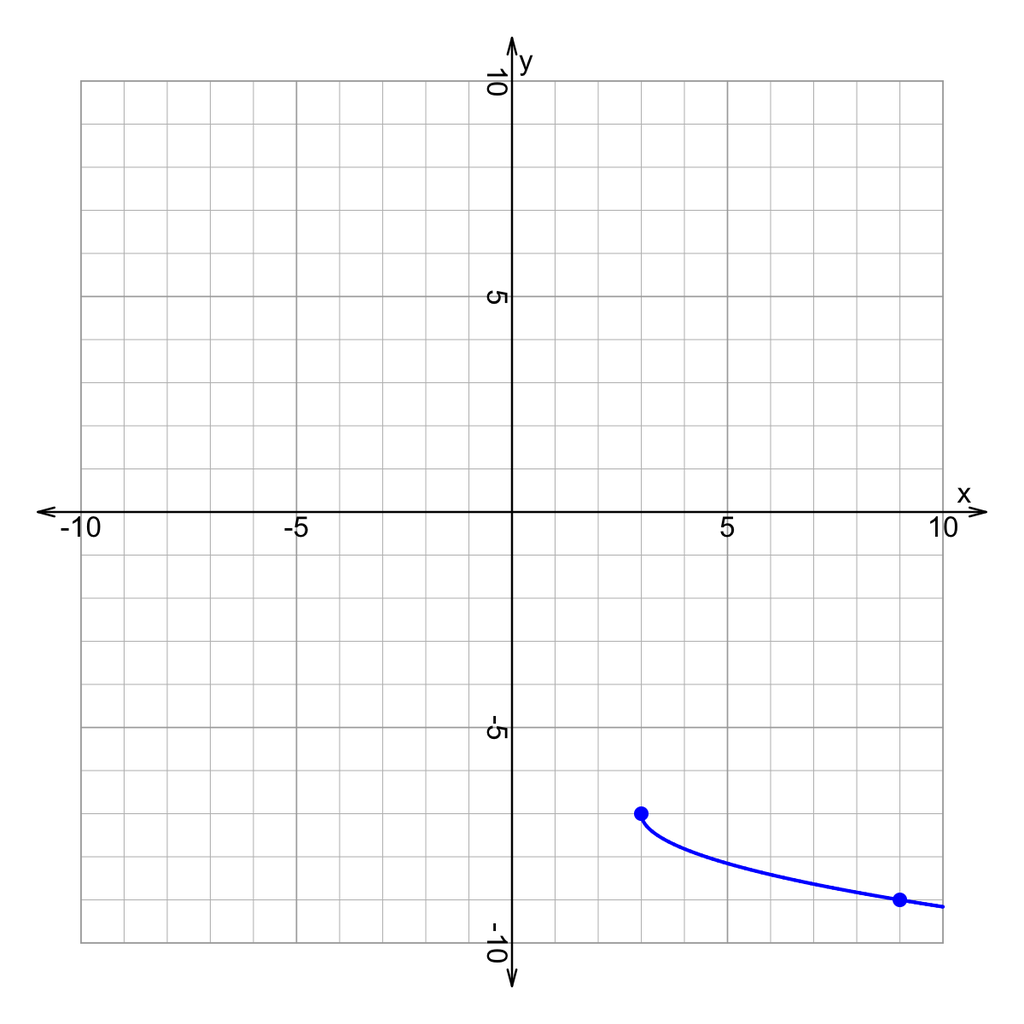

Notice, I've marked where the curve intersects the lattice points exactly. These points are where $x$ and $y$ are both integers. (*On the midterm, these points might not be marked.*)

Find the values of the parameters:

- $m=$
- $p=$
- $h=$
- $k=$

I recommend opening up [Desmos](https://www.desmos.com/calculator) and typing in $y~=~m\sqrt{\frac{1}{p}(x-h)}+k$, using sliders for $m$, $p$, $h$, and $k$. Then see what happens as you adjust each slider. You might also add points $(h,k)$ and $(h+p,k+m)$ to see where those move.

The given equation represents a transformation that is best thought of as stretches and then shifts. Imagine the parent function stretched vertically by factor $m$ and horizontally by factor $p$. Then, the parent function is shifted horizontally by distance $h$ and vertically by distance $k$.

The parent function, $y=\sqrt{x}$, has its endpoint at the origin. This point on the curve is unaffected by the stretches, so its corresponding point at $(3,-7)$ represents the shifts only.

$$h=3$$
$$k=-7$$

The parent function also goes through $(1,1)$. Because both stretches are integer multipliers, we know the corresponding point will be a lattice point on the curve. This key lattice point on the curve is at $(9,-9)$. We can find $m$ and $p$ by comparing this point to the endpoint.

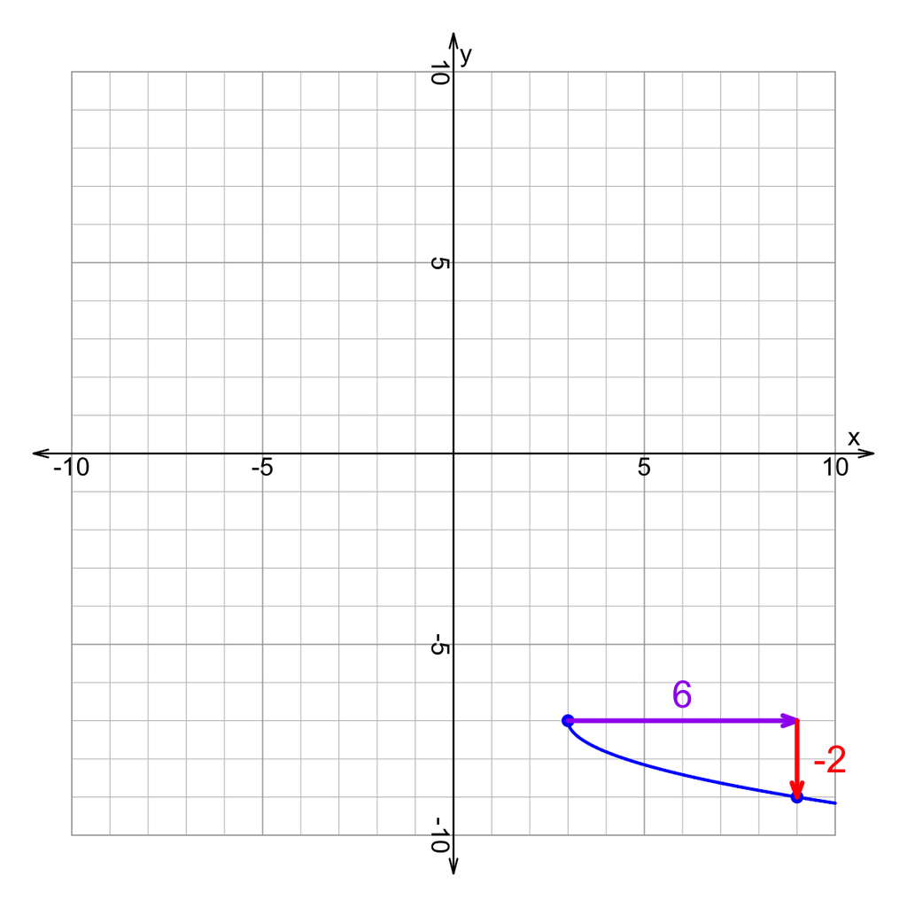

- $m=-2$
- $p=6$
- $h=3$
- $k=-7$

Thus, the equation of the curve is
$$y=-2\sqrt{\frac{1}{6}(x-3)}-7$$

A transformed square-root function was constructed by randomly choosing integers for the values of $m$, $p$, $h$, and $k$ in the equation below.

$$y~=~m\sqrt{\frac{1}{p}(x-h)}+k$$

The equation's curve is plotted below:

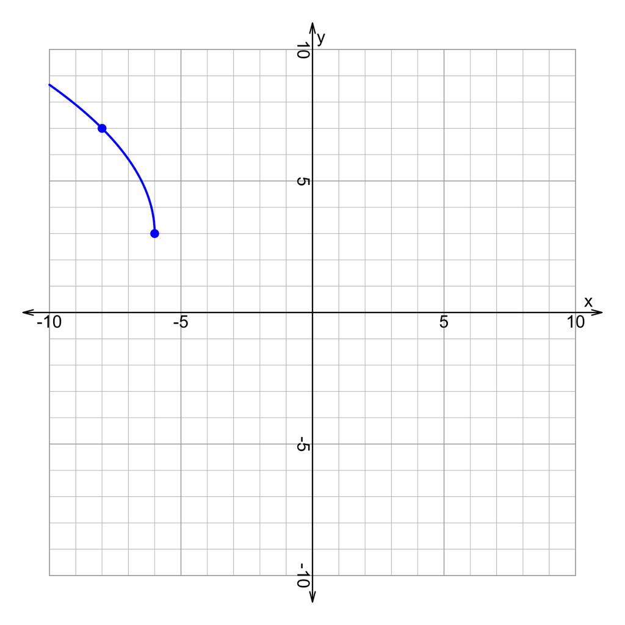

Notice, I've marked where the curve intersects the lattice points exactly. These points are where $x$ and $y$ are both integers. (*On the midterm, these points might not be marked.*)

Find the values of the parameters:

- $m=$
- $p=$
- $h=$
- $k=$

I recommend opening up [Desmos](https://www.desmos.com/calculator) and typing in $y~=~m\sqrt{\frac{1}{p}(x-h)}+k$, using sliders for $m$, $p$, $h$, and $k$. Then see what happens as you adjust each slider. You might also add points $(h,k)$ and $(h+p,k+m)$ to see where those move.

The given equation represents a transformation that is best thought of as stretches and then shifts. Imagine the parent function stretched vertically by factor $m$ and horizontally by factor $p$. Then, the parent function is shifted horizontally by distance $h$ and vertically by distance $k$.

The parent function, $y=\sqrt{x}$, has its endpoint at the origin. This point on the curve is unaffected by the stretches, so its corresponding point at $(-6,3)$ represents the shifts only.

$$h=-6$$
$$k=3$$

The parent function also goes through $(1,1)$. Because both stretches are integer multipliers, we know the corresponding point will be a lattice point on the curve. This key lattice point on the curve is at $(-8,7)$. We can find $m$ and $p$ by comparing this point to the endpoint.

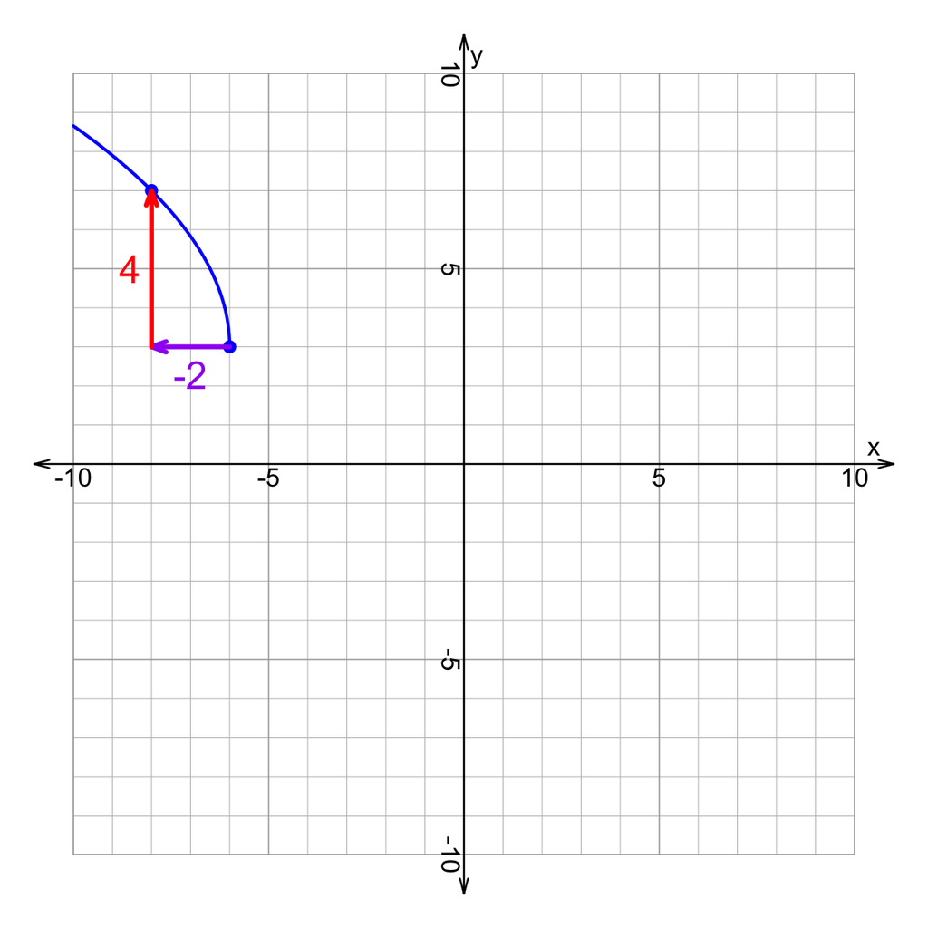

- $m=4$
- $p=-2$
- $h=-6$
- $k=3$

Thus, the equation of the curve is
$$y=4\sqrt{\frac{1}{-2}(x+6)}+3$$

A transformed square-root function was constructed by randomly choosing integers for the values of $m$, $p$, $h$, and $k$ in the equation below.

$$y~=~m\sqrt{\frac{1}{p}(x-h)}+k$$

The equation's curve is plotted below:

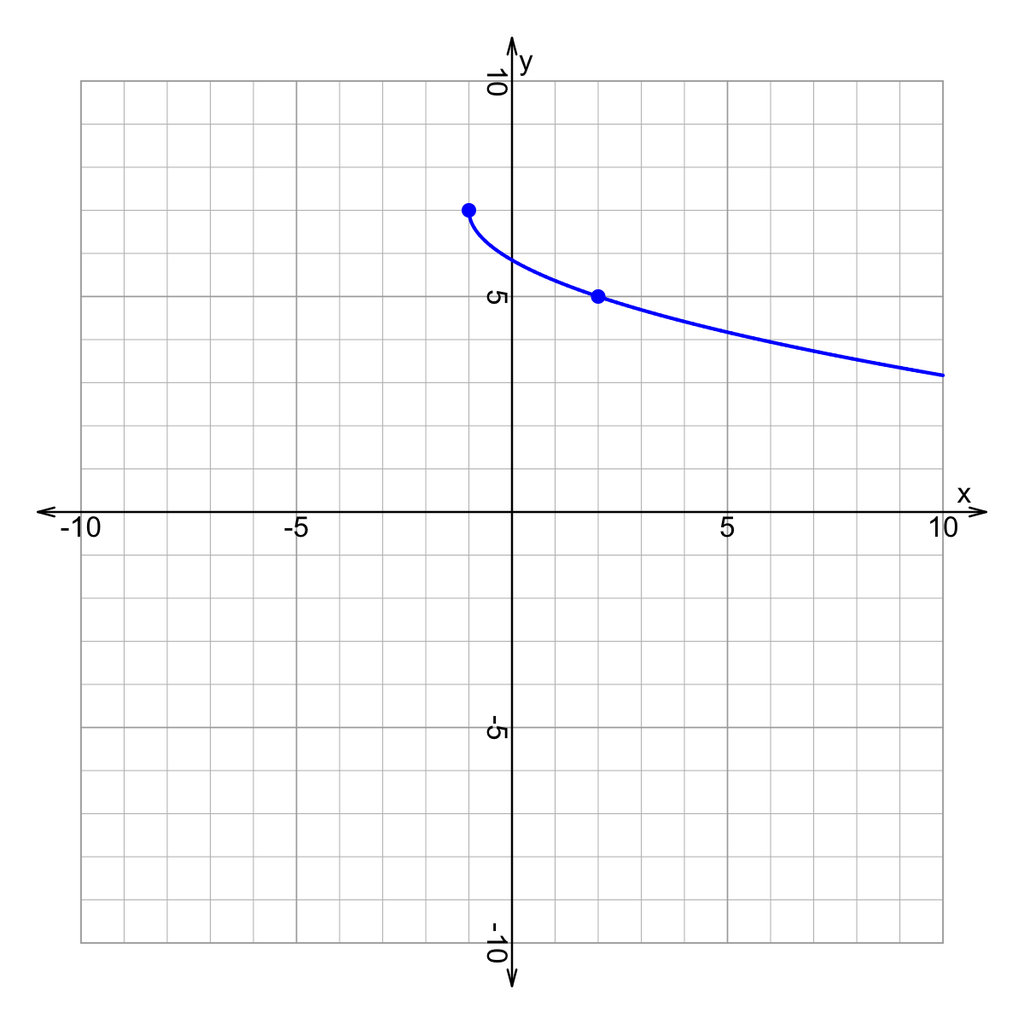

Notice, I've marked where the curve intersects the lattice points exactly. These points are where $x$ and $y$ are both integers. (*On the midterm, these points might not be marked.*)

Find the values of the parameters:

- $m=$
- $p=$
- $h=$
- $k=$

I recommend opening up [Desmos](https://www.desmos.com/calculator) and typing in $y~=~m\sqrt{\frac{1}{p}(x-h)}+k$, using sliders for $m$, $p$, $h$, and $k$. Then see what happens as you adjust each slider. You might also add points $(h,k)$ and $(h+p,k+m)$ to see where those move.

The given equation represents a transformation that is best thought of as stretches and then shifts. Imagine the parent function stretched vertically by factor $m$ and horizontally by factor $p$. Then, the parent function is shifted horizontally by distance $h$ and vertically by distance $k$.

The parent function, $y=\sqrt{x}$, has its endpoint at the origin. This point on the curve is unaffected by the stretches, so its corresponding point at $(-1,7)$ represents the shifts only.

$$h=-1$$
$$k=7$$

The parent function also goes through $(1,1)$. Because both stretches are integer multipliers, we know the corresponding point will be a lattice point on the curve. This key lattice point on the curve is at $(2,5)$. We can find $m$ and $p$ by comparing this point to the endpoint.

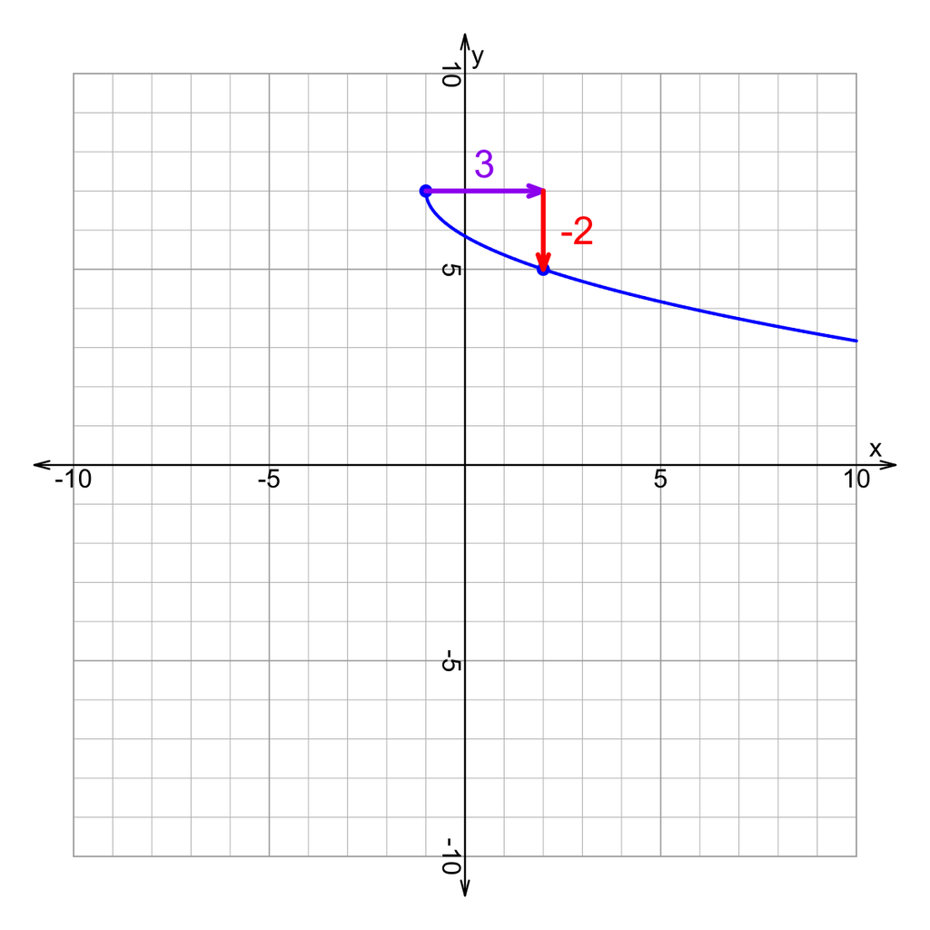

- $m=-2$
- $p=3$
- $h=-1$
- $k=7$

Thus, the equation of the curve is
$$y=-2\sqrt{\frac{1}{3}(x+1)}+7$$

A transformed square-root function was constructed by randomly choosing integers for the values of $m$, $p$, $h$, and $k$ in the equation below.

$$y~=~m\sqrt{\frac{1}{p}(x-h)}+k$$

The equation's curve is plotted below:

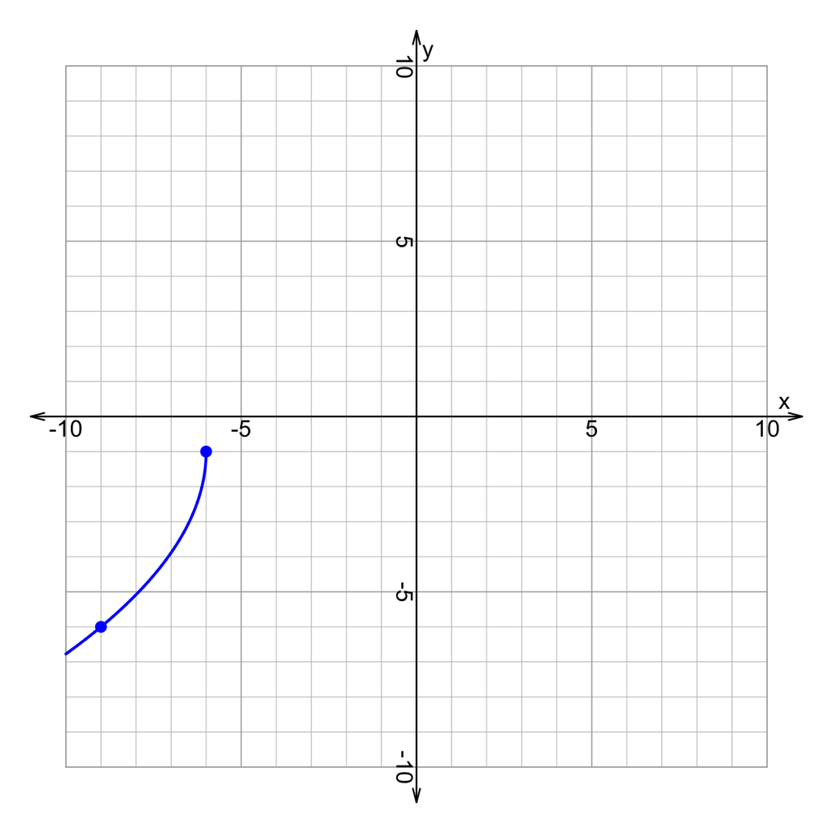

Notice, I've marked where the curve intersects the lattice points exactly. These points are where $x$ and $y$ are both integers. (*On the midterm, these points might not be marked.*)

Find the values of the parameters:

- $m=$
- $p=$
- $h=$
- $k=$

I recommend opening up [Desmos](https://www.desmos.com/calculator) and typing in $y~=~m\sqrt{\frac{1}{p}(x-h)}+k$, using sliders for $m$, $p$, $h$, and $k$. Then see what happens as you adjust each slider. You might also add points $(h,k)$ and $(h+p,k+m)$ to see where those move.

The given equation represents a transformation that is best thought of as stretches and then shifts. Imagine the parent function stretched vertically by factor $m$ and horizontally by factor $p$. Then, the parent function is shifted horizontally by distance $h$ and vertically by distance $k$.

The parent function, $y=\sqrt{x}$, has its endpoint at the origin. This point on the curve is unaffected by the stretches, so its corresponding point at $(-6,-1)$ represents the shifts only.

$$h=-6$$
$$k=-1$$

The parent function also goes through $(1,1)$. Because both stretches are integer multipliers, we know the corresponding point will be a lattice point on the curve. This key lattice point on the curve is at $(-9,-6)$. We can find $m$ and $p$ by comparing this point to the endpoint.

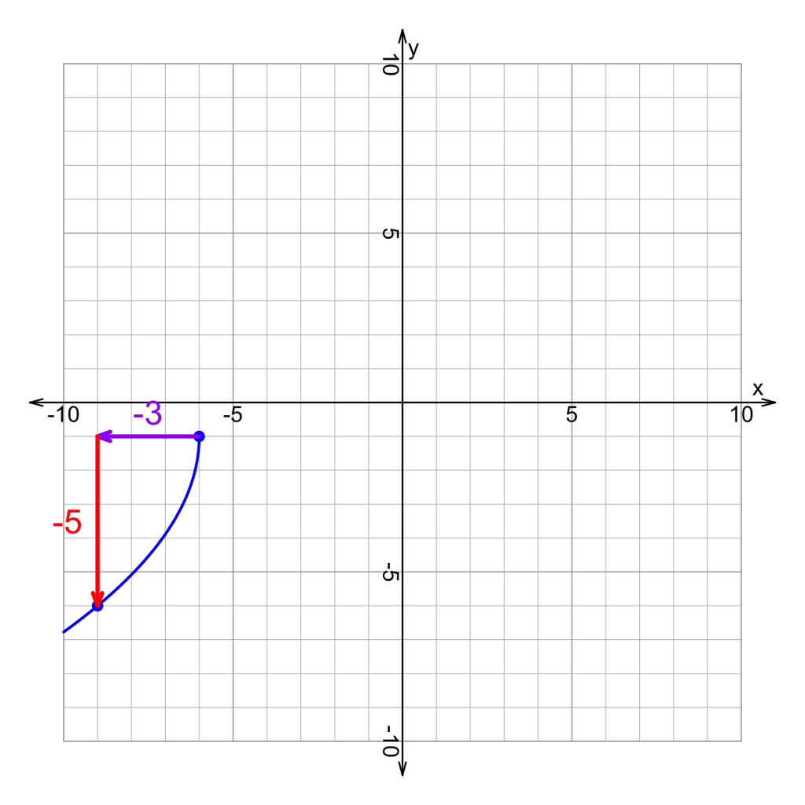

- $m=-5$
- $p=-3$
- $h=-6$
- $k=-1$

Thus, the equation of the curve is
$$y=-5\sqrt{\frac{1}{-3}(x+6)}-1$$

A transformed square-root function was constructed by randomly choosing integers for the values of $m$, $p$, $h$, and $k$ in the equation below.

$$y~=~m\sqrt{\frac{1}{p}(x-h)}+k$$

The equation's curve is plotted below:

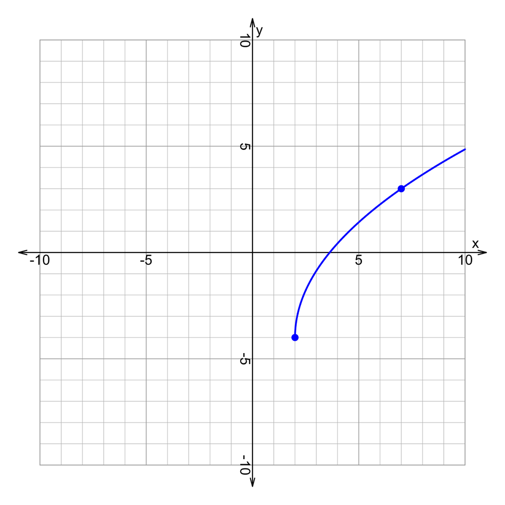

Notice, I've marked where the curve intersects the lattice points exactly. These points are where $x$ and $y$ are both integers. (*On the midterm, these points might not be marked.*)

Find the values of the parameters:

- $m=$
- $p=$
- $h=$
- $k=$

I recommend opening up [Desmos](https://www.desmos.com/calculator) and typing in $y~=~m\sqrt{\frac{1}{p}(x-h)}+k$, using sliders for $m$, $p$, $h$, and $k$. Then see what happens as you adjust each slider. You might also add points $(h,k)$ and $(h+p,k+m)$ to see where those move.

The given equation represents a transformation that is best thought of as stretches and then shifts. Imagine the parent function stretched vertically by factor $m$ and horizontally by factor $p$. Then, the parent function is shifted horizontally by distance $h$ and vertically by distance $k$.

The parent function, $y=\sqrt{x}$, has its endpoint at the origin. This point on the curve is unaffected by the stretches, so its corresponding point at $(2,-4)$ represents the shifts only.

$$h=2$$
$$k=-4$$

The parent function also goes through $(1,1)$. Because both stretches are integer multipliers, we know the corresponding point will be a lattice point on the curve. This key lattice point on the curve is at $(7,3)$. We can find $m$ and $p$ by comparing this point to the endpoint.

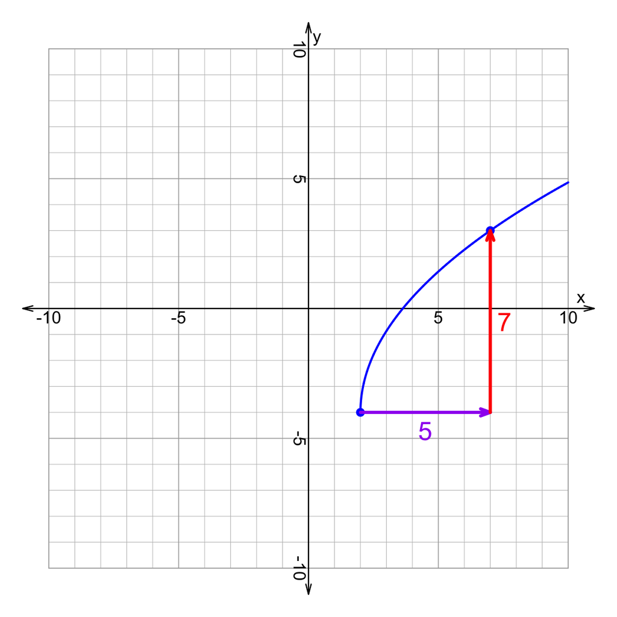

- $m=7$
- $p=5$
- $h=2$
- $k=-4$

Thus, the equation of the curve is
$$y=7\sqrt{\frac{1}{5}(x-2)}-4$$